# Video Empathy Analysis

Ellen Herschel, Colin McDaniel, Sherry Zhang

11/29/2021

# Read in Data

```r
# Import R data
alldata <- read.csv("~/Desktop/Coursework/Fall 2021/Multilevel Modeling/psyc575/Music_Sports_Empathy/Music_Sports_Empathy/Full Data Sets/sport_music_dat_mlm_long2.csv")

#alldata <- read.csv("sport_music_dat_mlm_long2.csv")

widedata<- read.csv("~/Desktop/Coursework/Fall 2021/Multilevel Modeling/psyc575/Music_Sports_Empathy/Music_Sports_Empathy/Full Data Sets/sport_music_dat_mlm_wide.csv")

#widedata<- read.csv("sport_music_dat_mlm_wide.csv")
```

#Factor, Get rid of NAs

```r
# Code Year and Group as factors
alldata$year <- factor(alldata$year)
alldata$group <- factor(alldata$group)

alldata$time<-as.integer(alldata$year)

# Remove NAs from data
alldata1<- drop_na(alldata, wasi_vci, group, empathy_conceptual, wasi_age)
```

# Mean-center variables

```r
# Mean-center Age
alldata1 <- alldata1 %>%
  group_by(id) %>%   # operate within individual
  mutate(age_pm = mean(wasi_age),   # create individual means (the same as `meanses`)
         age_pmc = wasi_age - age_pm) %>%   # cluster-mean centered
  ungroup()  # exit the "editing within groups" mode

alldata1 %>%
  select(id, wasi_age, age_pm, age_pmc)
```

| id | wasi_age | age_pm | age_pmc |
| --- | --- | --- | --- |
| M102 | 6.441096 | 8.474521 | -2.033424658 |
| M106 | 7.213699 | 8.690411 | -1.476712328 |
| M107 | 7.334247 | 9.258630 | -1.924383561 |
| M108 | 6.339726 | 8.255890 | -1.916164384 |
| M109 | 6.189041 | 8.153425 | -1.964383562 |
| M112 | 6.717808 | 8.091781 | -1.373972603 |
| M113 | 7.002740 | 8.903014 | -1.900273972 |
| S101 | 7.624658 | 9.191781 | -1.567123287 |
| S103 | 6.301370 | 8.325479 | -2.024109590 |
| S104 | 6.843836 | 8.927671 | -2.083835617 |

[output cut: 330 more lines]

```r
# Mean-center verbal ability
alldata1 <- alldata1 %>%
  group_by(id) %>%   # operate within individual
  mutate(verbal_pm = mean(wasi_vci),   # create individual means (the same as `meanses`)
         verbal_pmc = wasi_vci - verbal_pm) %>%   # cluster-mean centered
  ungroup()  # exit the "editing within groups" mode

alldata1 %>%
  select(id, wasi_vci, verbal_pm, verbal_pmc)
```

| id | wasi_vci | verbal_pm | verbal_pmc |
| --- | --- | --- | --- |
| M102 | 99 | 105.80000 | -6.8000000 |
| M106 | 98 | 96.00000 | 2.0000000 |
| M107 | 86 | 76.60000 | 9.4000000 |
| M108 | 102 | 113.40000 | -11.4000000 |
| M109 | 98 | 105.20000 | -7.2000000 |
| M112 | 105 | 105.50000 | -0.5000000 |
| M113 | 85 | 89.20000 | -4.2000000 |
| S101 | 77 | 81.25000 | -4.2500000 |
| S103 | 105 | 104.20000 | 0.8000000 |
| S104 | 102 | 97.20000 | 4.8000000 |

[output cut: 330 more lines]

```r
datasummary_skim(alldata1 %>%
                   select(empathy_conceptual, time, wasi_age, group, wasi_vci ))
```

Unique (#)

Missing (%)

Mean

SD

Min

Median

Max

empathy_conceptual

13

0

0.8

0.3

0.0

0.8

1.0

time

5

0

2.8

1.4

1.0

3.0

5.0

wasi_age

313

0

8.7

1.6

5.7

8.6

12.1

[figure not shown]

wasi_vci

61

0

98.7

12.1

68.0

98.5

142.0

# Check for differences in baseline Age

```r
widedata$group <- factor(widedata$group)

agebase<-aov(wasi_age_Y1~group, widedata)
summary(agebase)
```

```
##             Df Sum Sq Mean Sq F value  Pr(>F)
## group        2  2.757  1.3786    5.11 0.00815 **
## Residuals   80 21.582  0.2698
## ---
## Signif. codes:  0 '***' 0.001 '**' 0.01 '*' 0.05 '.' 0.1 ' ' 1
```

# Attrition Analysis

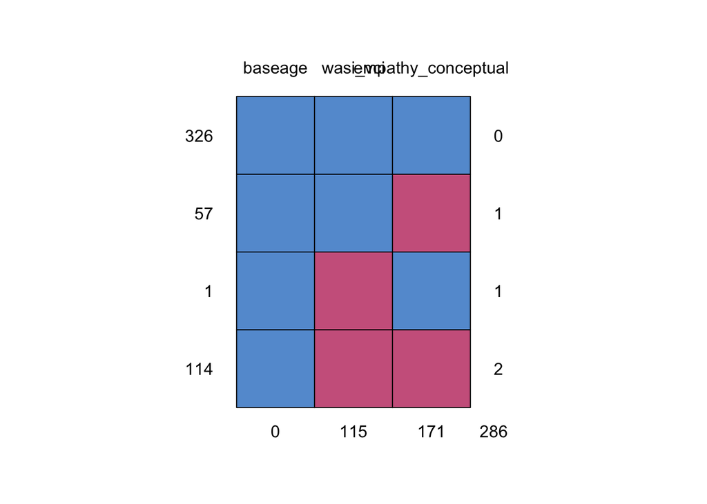

```
##     baseage wasi_vci empathy_conceptual
## 326       1        1                  1   0
## 57        1        1                  0   1
## 1         1        0                  1   1
## 114       1        0                  0   2
##           0      115                171 286
```

```r
# Replace incorrectly placed 0s with NA
alldata$empathy_conceptual[alldata$empathy_conceptual == 0] <- NA

# Examine missing data patterns
md.pattern(alldata[,c("empathy_conceptual", "baseage", "wasi_vci")])
```

```r
# Attrition analysis setup
alldata$miss_empathy_conceptual <- ifelse(is.na(alldata$empathy_conceptual), 1, 0)
alldata$miss_baseage <- ifelse(is.na(alldata$baseage), 1, 0)
alldata$miss_wasi_vci <- ifelse(is.na(alldata$wasi_vci), 1, 0)

# Test whether empathy_conceptual is missing completely at random
t.test(alldata$baseage[alldata$miss_empathy_conceptual==0], alldata$baseage[alldata$miss_empathy_conceptual==1], alternative = "two.sided", conf.level = .95, var.equal = TRUE)
```

```
##
##  Two Sample t-test
##
## data:  alldata$baseage[alldata$miss_empathy_conceptual == 0] and alldata$baseage[alldata$miss_empathy_conceptual == 1]
## t = 0.67979, df = 496, p-value = 0.497
## alternative hypothesis: true difference in means is not equal to 0
## 95 percent confidence interval:
##  -0.06576958  0.13535824
## sample estimates:
## mean of x mean of y
##  6.821256  6.786462
```

```r
t.test(alldata$wasi_vci[alldata$miss_empathy_conceptual==0], alldata$wasi_vci[alldata$miss_empathy_conceptual==1], alternative = "two.sided", conf.level = .95, var.equal = TRUE)
```

```
##
##  Two Sample t-test
##
## data:  alldata$wasi_vci[alldata$miss_empathy_conceptual == 0] and alldata$wasi_vci[alldata$miss_empathy_conceptual == 1]
## t = 2.7238, df = 381, p-value = 0.006751
## alternative hypothesis: true difference in means is not equal to 0
## 95 percent confidence interval:
##  1.289189 7.981288
## sample estimates:
## mean of x mean of y
##  98.82822  94.19298
```

```r
# Test whether wasi_vci is missing completely at random
t.test(alldata$empathy_conceptual[alldata$miss_wasi_vci==0], alldata$empathy_conceptual[alldata$miss_wasi_vci==1], alternative = "two.sided", conf.level = .95, var.equal = TRUE)
```

```
##
##  Two Sample t-test
##
## data:  alldata$empathy_conceptual[alldata$miss_wasi_vci == 0] and alldata$empathy_conceptual[alldata$miss_wasi_vci == 1]
## t = 1.9921, df = 325, p-value = 0.0472
## alternative hypothesis: true difference in means is not equal to 0
## 95 percent confidence interval:
##  0.005846335 0.932599473
## sample estimates:
## mean of x mean of y
## 0.8025562 0.3333333
```

```r
t.test(alldata$baseage[alldata$miss_wasi_vci==0], alldata$baseage[alldata$miss_wasi_vci==1], alternative = "two.sided", conf.level = .95, var.equal = TRUE)
```

```
##
##  Two Sample t-test
##
## data:  alldata$baseage[alldata$miss_wasi_vci == 0] and alldata$baseage[alldata$miss_wasi_vci == 1]
## t = 0.80517, df = 496, p-value = 0.4211
## alternative hypothesis: true difference in means is not equal to 0
## 95 percent confidence interval:
##  -0.06686212  0.15971411
## sample estimates:
## mean of x mean of y
##  6.820029  6.773603
```

# Check assumptions

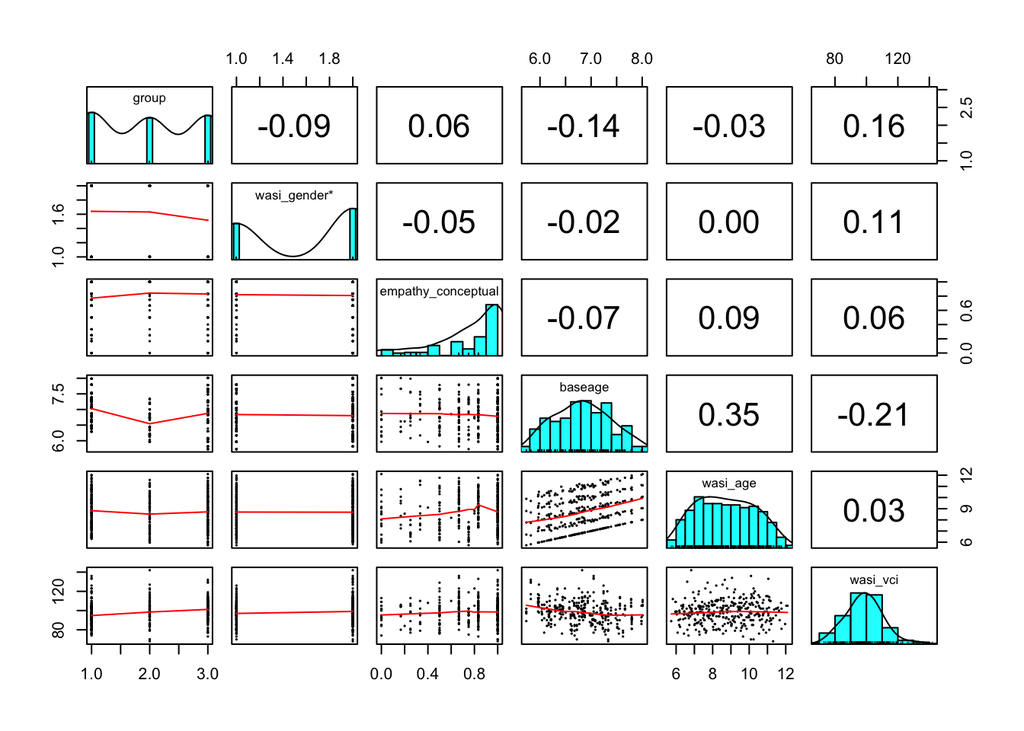

```r
alldata1 %>%
  # Select the variables to be used
  select(group, wasi_gender, empathy_conceptual, baseage, wasi_age, wasi_vci) %>%
  psych::pairs.panels(ellipses = FALSE, cex = 0.2, cex.cor = 1)
```

The data for baseage, and wasi_vci (the continuous variables being included in the model) appear relatively normal. Data for empathy conceptial is skewed.

# Write Down Model Equations

Lv-1:
$$\mathrm{empathyconceptual}_{ti} = \beta_{0i} + \beta_{1i}\mathrm{time}_{ti} + \beta_{2i}\mathrm{verbalpmc}_{ti} + e_{ti}$$
Lv-2:
$$\beta_{0i} = \gamma_{00} + \gamma_{01}\mathrm{baseage}_i + \gamma_{02}\mathrm{verbalpm_i} + \gamma_{03}\mathrm{group}_i+ u_{0i}$$
$$\beta_{1i} = \gamma_{10} + \gamma_{11}\mathrm{verbalpm}_i + \gamma_{12}\mathrm{group}_i + u_{1i}$$
$$\beta_{2i} = \gamma_{20} + \gamma_{21}\mathrm{baseage}_i + \gamma_{22}\mathrm{group}_i + u_{2i}$$

# Baseline Model

```r
#model with just base interaction of year and group, and no random slopes
m0 <- glmmTMB(empathy_conceptual ~ time + (1 | id),
    data = alldata1,
)

summary(m0)
```

```
##  Family: gaussian  ( identity )
## Formula:          empathy_conceptual ~ time + (1 | id)
## Data: alldata1
##
##      AIC      BIC   logLik deviance df.resid
##     68.8     84.1    -30.4     60.8      336
##
## Random effects:
##
## Conditional model:
##  Groups   Name        Variance Std.Dev.
##  id       (Intercept) 0.02886  0.1699
##  Residual             0.05318  0.2306
## Number of obs: 340, groups:  id, 83
##
## Dispersion estimate for gaussian family (sigma^2): 0.0532
##
## Conditional model:
##             Estimate Std. Error z value Pr(>|z|)
## (Intercept) 0.700808   0.033591  20.863   <2e-16 ***
## time        0.022371   0.009042   2.474   0.0134 *
## ---
## Signif. codes:  0 '***' 0.001 '**' 0.01 '*' 0.05 '.' 0.1 ' ' 1
```

# Add in and test covariates and random slopes

```r
#model

m1 <- glmmTMB(empathy_conceptual ~ time + group + (1 | id),
    data = alldata1,
)

summary(m1)
```

```
##  Family: gaussian  ( identity )
## Formula:          empathy_conceptual ~ time + group + (1 | id)
## Data: alldata1
##
##      AIC      BIC   logLik deviance df.resid
##     70.4     93.4    -29.2     58.4      334
##
## Random effects:
##
## Conditional model:
##  Groups   Name        Variance Std.Dev.
##  id       (Intercept) 0.02787  0.1669
##  Residual             0.05309  0.2304
## Number of obs: 340, groups:  id, 83
##
## Dispersion estimate for gaussian family (sigma^2): 0.0531
##
## Conditional model:
##             Estimate Std. Error z value Pr(>|z|)
## (Intercept)  0.65671    0.04524  14.515   <2e-16 ***
## time         0.02231    0.00903   2.471   0.0135 *
## groupMusic   0.08485    0.05575   1.522   0.1280
## groupSport   0.05310    0.05497   0.966   0.3341
## ---
## Signif. codes:  0 '***' 0.001 '**' 0.01 '*' 0.05 '.' 0.1 ' ' 1
```

```r
anova(m0, m1)
```

|  | Df | AIC | BIC | logLik | deviance | Chisq | Chi Df | Pr(>Chisq) |
| --- | --- | --- | --- | --- | --- | --- | --- | --- |
| m0 | 4 | 68.76997 | 84.08575 | -30.38498 | 60.76997 | NA | NA | NA |
| m1 | 6 | 70.40009 | 93.37377 | -29.20005 | 58.40009 | 2.369876 | 2 | 0.3057652 |

```r
#no sig

#add interaction of year and group
m2 <- glmmTMB(empathy_conceptual ~ time*group + (1 | id),
    data = alldata1,
)
summary(m2)
```

```
##  Family: gaussian  ( identity )
## Formula:          empathy_conceptual ~ time * group + (1 | id)
## Data: alldata1
##
##      AIC      BIC   logLik deviance df.resid
##     69.5    100.2    -26.8     53.5      332
##
## Random effects:
##
## Conditional model:
##  Groups   Name        Variance Std.Dev.
##  id       (Intercept) 0.02818  0.1679
##  Residual             0.05209  0.2282
## Number of obs: 340, groups:  id, 83
##
## Dispersion estimate for gaussian family (sigma^2): 0.0521
##
## Conditional model:
##                 Estimate Std. Error z value Pr(>|z|)
## (Intercept)      0.64945    0.05598  11.602   <2e-16 ***
## time             0.02499    0.01522   1.642    0.101
## groupMusic       0.02715    0.08163   0.333    0.739
## groupSport       0.12794    0.08019   1.595    0.111
## time:groupMusic  0.02130    0.02207   0.965    0.335
## time:groupSport -0.02753    0.02161  -1.274    0.203
## ---
## Signif. codes:  0 '***' 0.001 '**' 0.01 '*' 0.05 '.' 0.1 ' ' 1
```

```r
anova(m1, m2)
```

|  | Df | AIC | BIC | logLik | deviance | Chisq | Chi Df | Pr(>Chisq) |
| --- | --- | --- | --- | --- | --- | --- | --- | --- |
| m1 | 6 | 70.40009 | 93.37377 | -29.20005 | 58.40009 | NA | NA | NA |
| m2 | 8 | 69.53942 | 100.17098 | -26.76971 | 53.53942 | 4.860677 | 2 | 0.08800702 |

```r
#yes sig 0.08/2

#add more covariates
#verbal (person mean-centered)
m3 <- glmmTMB(empathy_conceptual ~ time*group + verbal_pmc + (1 | id),
    data = alldata1,
)
summary(m3)
```

```
##  Family: gaussian  ( identity )
## Formula:          empathy_conceptual ~ time * group + verbal_pmc + (1 | id)
## Data: alldata1
##
##      AIC      BIC   logLik deviance df.resid
##     70.8    105.3    -26.4     52.8      331
##
## Random effects:
##
## Conditional model:
##  Groups   Name        Variance Std.Dev.
##  id       (Intercept) 0.02821  0.1680
##  Residual             0.05195  0.2279
## Number of obs: 340, groups:  id, 83
##
## Dispersion estimate for gaussian family (sigma^2): 0.0519
##
## Conditional model:
##                  Estimate Std. Error z value Pr(>|z|)
## (Intercept)      0.652986   0.056097  11.640   <2e-16 ***
## time             0.023675   0.015282   1.549    0.121
## groupMusic       0.027162   0.081570   0.333    0.739
## groupSport       0.127830   0.080127   1.595    0.111
## verbal_pmc       0.001784   0.002141   0.833    0.405
## time:groupMusic  0.021309   0.022045   0.967    0.334
## time:groupSport -0.027474   0.021585  -1.273    0.203
## ---
## Signif. codes:  0 '***' 0.001 '**' 0.01 '*' 0.05 '.' 0.1 ' ' 1
```

```r
anova(m2, m3)
```

|  | Df | AIC | BIC | logLik | deviance | Chisq | Chi Df | Pr(>Chisq) |
| --- | --- | --- | --- | --- | --- | --- | --- | --- |
| m2 | 8 | 69.53942 | 100.1710 | -26.76971 | 53.53942 | NA | NA | NA |
| m3 | 9 | 70.84565 | 105.3062 | -26.42283 | 52.84565 | 0.6937639 | 1 | 0.4048871 |

```r
#is not sig

#verbal (person mean)
m4 <- glmmTMB(empathy_conceptual ~ time*group + verbal_pm + (1 | id),
    data = alldata1,
)
summary(m4)
```

```
##  Family: gaussian  ( identity )
## Formula:          empathy_conceptual ~ time * group + verbal_pm + (1 | id)
## Data: alldata1
##
##      AIC      BIC   logLik deviance df.resid
##     71.4    105.9    -26.7     53.4      331
##
## Random effects:
##
## Conditional model:
##  Groups   Name        Variance Std.Dev.
##  id       (Intercept) 0.02810  0.1676
##  Residual             0.05209  0.2282
## Number of obs: 340, groups:  id, 83
##
## Dispersion estimate for gaussian family (sigma^2): 0.0521
##
## Conditional model:
##                   Estimate Std. Error z value Pr(>|z|)
## (Intercept)      0.5774643  0.2178093   2.651  0.00802 **
## time             0.0249945  0.0152200   1.642  0.10055
## groupMusic       0.0255529  0.0817325   0.313  0.75455
## groupSport       0.1258230  0.0803929   1.565  0.11756
## verbal_pm        0.0007468  0.0021839   0.342  0.73240
## time:groupMusic  0.0212695  0.0220735   0.964  0.33526
## time:groupSport -0.0278278  0.0216300  -1.286  0.19826
## ---
## Signif. codes:  0 '***' 0.001 '**' 0.01 '*' 0.05 '.' 0.1 ' ' 1
```

```r
anova(m2, m4)
```

|  | Df | AIC | BIC | logLik | deviance | Chisq | Chi Df | Pr(>Chisq) |
| --- | --- | --- | --- | --- | --- | --- | --- | --- |
| m2 | 8 | 69.53942 | 100.1710 | -26.76971 | 53.53942 | NA | NA | NA |
| m4 | 9 | 71.42263 | 105.8831 | -26.71131 | 53.42263 | 0.1167882 | 1 | 0.7325444 |

```r
#is not sig

# age
m5 <- glmmTMB(empathy_conceptual ~ time*group + baseage + (1 | id),
    data = alldata1,
)
summary(m5)
```

```
##  Family: gaussian  ( identity )
## Formula:          empathy_conceptual ~ time * group + baseage + (1 | id)
## Data: alldata1
##
##      AIC      BIC   logLik deviance df.resid
##     71.3    105.7    -26.6     53.3      331
##
## Random effects:
##
## Conditional model:
##  Groups   Name        Variance Std.Dev.
##  id       (Intercept) 0.02809  0.1676
##  Residual             0.05207  0.2282
## Number of obs: 340, groups:  id, 83
##
## Dispersion estimate for gaussian family (sigma^2): 0.0521
##
## Conditional model:
##                 Estimate Std. Error z value Pr(>|z|)
## (Intercept)      0.80569    0.31408   2.565   0.0103 *
## time             0.02528    0.01523   1.660   0.0970 .
## groupMusic       0.01760    0.08374   0.210   0.8335
## groupSport       0.12558    0.08027   1.564   0.1177
## baseage         -0.02238    0.04426  -0.506   0.6131
## time:groupMusic  0.02100    0.02208   0.951   0.3414
## time:groupSport -0.02791    0.02162  -1.291   0.1968
## ---
## Signif. codes:  0 '***' 0.001 '**' 0.01 '*' 0.05 '.' 0.1 ' ' 1
```

```r
anova(m2, m5)
```

|  | Df | AIC | BIC | logLik | deviance | Chisq | Chi Df | Pr(>Chisq) |
| --- | --- | --- | --- | --- | --- | --- | --- | --- |
| m2 | 8 | 69.53942 | 100.1710 | -26.76971 | 53.53942 | NA | NA | NA |
| m5 | 9 | 71.28400 | 105.7445 | -26.64200 | 53.28400 | 0.2554143 | 1 | 0.6132883 |

```r
# is not sig

#gender
m6 <- glmmTMB(empathy_conceptual ~ time*group + wasi_gender + (1 | id),
    data = alldata1,
)
summary(m6)
```

```
##  Family: gaussian  ( identity )
## Formula:          empathy_conceptual ~ time * group + wasi_gender + (1 | id)
## Data: alldata1
##
##      AIC      BIC   logLik deviance df.resid
##     71.2    105.7    -26.6     53.2      331
##
## Random effects:
##
## Conditional model:
##  Groups   Name        Variance Std.Dev.
##  id       (Intercept) 0.02795  0.1672
##  Residual             0.05211  0.2283
## Number of obs: 340, groups:  id, 83
##
## Dispersion estimate for gaussian family (sigma^2): 0.0521
##
## Conditional model:
##                 Estimate Std. Error z value Pr(>|z|)
## (Intercept)      0.66471    0.06219  10.689   <2e-16 ***
## time             0.02521    0.01523   1.656   0.0978 .
## groupMusic       0.02760    0.08154   0.338   0.7350
## groupSport       0.12739    0.08010   1.590   0.1118
## wasi_genderm    -0.02597    0.04626  -0.561   0.5745
## time:groupMusic  0.02113    0.02208   0.957   0.3386
## time:groupSport -0.02805    0.02163  -1.296   0.1948
## ---
## Signif. codes:  0 '***' 0.001 '**' 0.01 '*' 0.05 '.' 0.1 ' ' 1
```

```r
anova(m2, m6)
```

|  | Df | AIC | BIC | logLik | deviance | Chisq | Chi Df | Pr(>Chisq) |
| --- | --- | --- | --- | --- | --- | --- | --- | --- |
| m2 | 8 | 69.53942 | 100.1710 | -26.76971 | 53.53942 | NA | NA | NA |
| m6 | 9 | 71.22532 | 105.6858 | -26.61266 | 53.22532 | 0.3141002 | 1 | 0.575175 |

```r
#not sig, gender doesnt seem to improve the model


#test for random slopes

#time
m2.1 <- glmmTMB(empathy_conceptual ~ time*group +  (time | id),
    data = alldata1,
)
summary(m2.1)
```

```
##  Family: gaussian  ( identity )
## Formula:          empathy_conceptual ~ time * group + (time | id)
## Data: alldata1
##
##      AIC      BIC   logLik deviance df.resid
##     73.5    111.8    -26.8     53.5      330
##
## Random effects:
##
## Conditional model:
##  Groups   Name        Variance  Std.Dev.  Corr
##  id       (Intercept) 2.818e-02 1.679e-01
##           time        8.576e-22 2.928e-11 1.00
##  Residual             5.209e-02 2.282e-01
## Number of obs: 340, groups:  id, 83
##
## Dispersion estimate for gaussian family (sigma^2): 0.0521
##
## Conditional model:
##                 Estimate Std. Error z value Pr(>|z|)
## (Intercept)      0.64945    0.05598  11.602   <2e-16 ***
## time             0.02499    0.01522   1.642    0.101
## groupMusic       0.02715    0.08163   0.333    0.739
## groupSport       0.12794    0.08019   1.595    0.111
## time:groupMusic  0.02130    0.02207   0.965    0.335
## time:groupSport -0.02753    0.02161  -1.274    0.203
## ---
## Signif. codes:  0 '***' 0.001 '**' 0.01 '*' 0.05 '.' 0.1 ' ' 1
```

```r
anova(m2, m2.1)
```

|  | Df | AIC | BIC | logLik | deviance | Chisq | Chi Df | Pr(>Chisq) |
| --- | --- | --- | --- | --- | --- | --- | --- | --- |
| m2 | 8 | 69.53942 | 100.1710 | -26.76971 | 53.53942 | NA | NA | NA |
| m2.1 | 10 | 73.53942 | 111.8289 | -26.76971 | 53.53942 | 0 | 2 | 1 |

```r
#this is not sig

confint(m2, parm = "beta_")
```

```
##                        2.5 %     97.5 %    Estimate
## (Intercept)      0.539731827 0.75916076  0.64944629
## time            -0.004836641 0.05482319  0.02499327
## groupMusic      -0.132846562 0.18713846  0.02714595
## groupSport      -0.029225122 0.28509826  0.12793657
## time:groupMusic -0.021966180 0.06455738  0.02129560
## time:groupSport -0.069889881 0.01482713 -0.02753138
```

# Here’s our final model

```r
summary(m2)
```

```
##  Family: gaussian  ( identity )
## Formula:          empathy_conceptual ~ time * group + (1 | id)
## Data: alldata1
##
##      AIC      BIC   logLik deviance df.resid
##     69.5    100.2    -26.8     53.5      332
##
## Random effects:
##
## Conditional model:
##  Groups   Name        Variance Std.Dev.
##  id       (Intercept) 0.02818  0.1679
##  Residual             0.05209  0.2282
## Number of obs: 340, groups:  id, 83
##
## Dispersion estimate for gaussian family (sigma^2): 0.0521
##
## Conditional model:
##                 Estimate Std. Error z value Pr(>|z|)
## (Intercept)      0.64945    0.05598  11.602   <2e-16 ***
## time             0.02499    0.01522   1.642    0.101
## groupMusic       0.02715    0.08163   0.333    0.739
## groupSport       0.12794    0.08019   1.595    0.111
## time:groupMusic  0.02130    0.02207   0.965    0.335
## time:groupSport -0.02753    0.02161  -1.274    0.203
## ---
## Signif. codes:  0 '***' 0.001 '**' 0.01 '*' 0.05 '.' 0.1 ' ' 1
```

# Coefficient Table (msummary)

```r
msummary(m2,
  stars=TRUE)
```

|  | Model 1 |
| --- | --- |
| (Intercept) | 0.649*** |
|  | (0.056) |
| time | 0.025 |
|  | (0.015) |
| groupMusic | 0.027 |
|  | (0.082) |
| groupSport | 0.128 |
|  | (0.080) |
| time × groupMusic | 0.021 |
|  | (0.022) |
| time × groupSport | −0.028 |
|  | (0.022) |
| SD (Intercept) | 0.168 |
| SD (Observations) | 0.228 |
| Num.Obs. | 340 |
| R2 Marg. | 0.037 |
| R2 Cond. | 0.375 |
| AIC | 69.5 |
| BIC | 100.2 |
| ICC | 0.4 |
| RMSE | 0.21 |

+ p < 0.1, * p < 0.05, ** p < 0.01, *** p < 0.001

# Plot

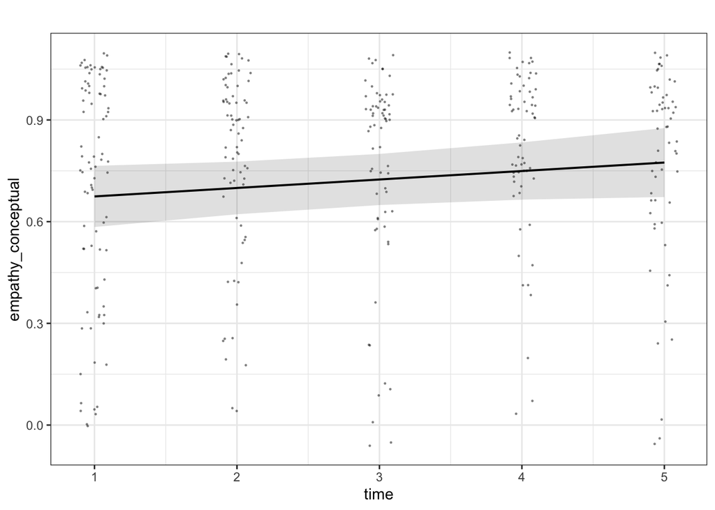

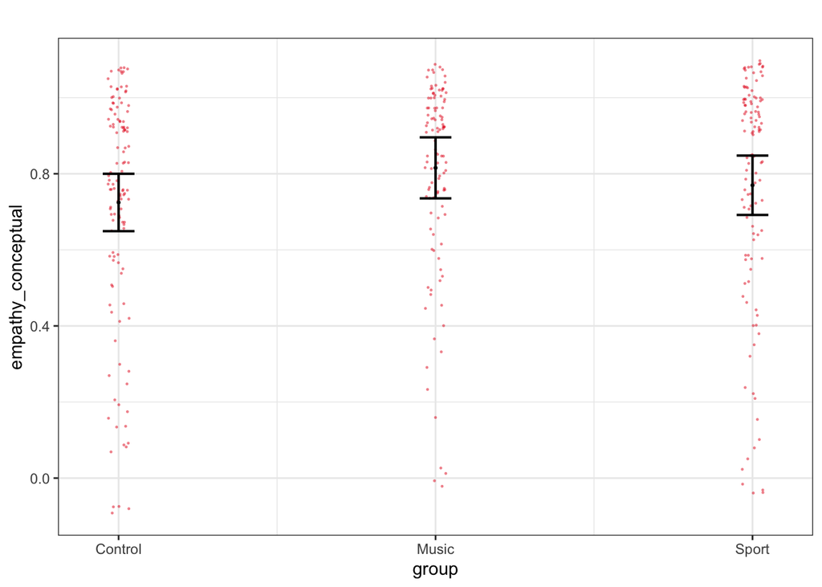

```r
plot_model(m2,
    type = "pred", show.data = TRUE,
    title = "", dot.size = 0.5,
    jitter = 0.1
)
```

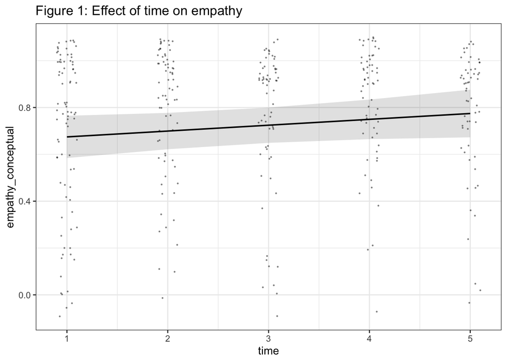

```r
plot_model(m2,
    type = "pred", terms = "time",
    show.data = TRUE, jitter = 0.1,
    title = "Figure 1: Effect of time on empathy ",
    dot.size = 0.5
)
```

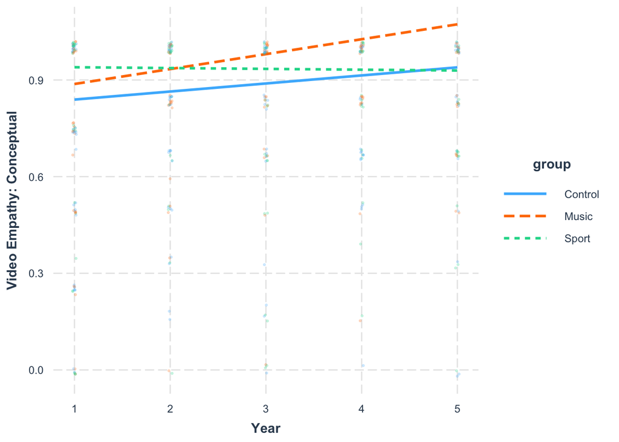

```r
# Interaction plot (year:group)
interact_plot(m2,
              pred = "time",
              modx = "group",
              plot.points = TRUE,
              point.size = 0.5,
              point.alpha = 0.2,
              jitter = 0.02,
              x.label = "Year",
              y.label = "Video Empathy: Conceptual")
```

# Let’s do it all again, but this time with empathy_exact instead

#Factor, Get rid of NAs

```r
alldata$year <- factor(alldata$year)
alldata$group <- factor(alldata$group)

alldata$time<-as.integer(alldata$year)


alldata1<- drop_na(alldata, wasi_vci, group, empathy_exact, wasi_age)
```

# Mean-center Age

```r
alldata1 <- alldata1 %>%
  group_by(id) %>%   # operate within individual
  mutate(age_pm = mean(wasi_age),   # create individual means (the same as `meanses`)
         age_pmc = wasi_age - age_pm) %>%   # cluster-mean centered
  ungroup()  # exit the "editing within groups" mode

alldata1 %>%
  select(id, wasi_age, age_pm, age_pmc)
```

| id | wasi_age | age_pm | age_pmc |
| --- | --- | --- | --- |
| M102 | 6.441096 | 8.474521 | -2.033424658 |
| M106 | 7.213699 | 8.690411 | -1.476712328 |
| M107 | 7.334247 | 9.258630 | -1.924383561 |
| M108 | 6.339726 | 8.255890 | -1.916164384 |
| M109 | 6.189041 | 8.153425 | -1.964383562 |
| M112 | 6.717808 | 8.091781 | -1.373972603 |
| M113 | 7.002740 | 8.903014 | -1.900273972 |
| S101 | 7.624658 | 9.191781 | -1.567123287 |
| S103 | 6.301370 | 8.325479 | -2.024109590 |
| S104 | 6.843836 | 8.927671 | -2.083835617 |

[output cut: 330 more lines]

```r
#verbal ability
alldata1 <- alldata1 %>%
  group_by(id) %>%   # operate within individual
  mutate(verbal_pm = mean(wasi_vci),   # create individual means (the same as `meanses`)
         verbal_pmc = wasi_vci - verbal_pm) %>%   # cluster-mean centered
  ungroup()  # exit the "editing within groups" mode

alldata1 %>%
  select(id, wasi_vci, verbal_pm, verbal_pmc)
```

| id | wasi_vci | verbal_pm | verbal_pmc |
| --- | --- | --- | --- |
| M102 | 99 | 105.80000 | -6.8000000 |
| M106 | 98 | 96.00000 | 2.0000000 |
| M107 | 86 | 76.60000 | 9.4000000 |
| M108 | 102 | 113.40000 | -11.4000000 |
| M109 | 98 | 105.20000 | -7.2000000 |
| M112 | 105 | 105.50000 | -0.5000000 |
| M113 | 85 | 89.20000 | -4.2000000 |
| S101 | 77 | 81.25000 | -4.2500000 |
| S103 | 105 | 104.20000 | 0.8000000 |
| S104 | 102 | 97.20000 | 4.8000000 |

[output cut: 330 more lines]

```r
datasummary_skim(alldata1 %>%
                   select(empathy_exact, time, wasi_age, group, wasi_vci ))
```

Unique (#)

Missing (%)

Mean

SD

Min

Median

Max

empathy_exact

12

0

0.6

0.3

0.0

0.7

1.0

time

5

0

2.8

1.4

1.0

3.0

5.0

wasi_age

313

0

8.7

1.6

5.7

8.6

12.1

[figure not shown]

wasi_vci

61

0

98.7

12.1

68.0

98.5

142.0

# Check for differences in baseline Age

```r
widedata$group <- factor(widedata$group)

agebase<-aov(wasi_age_Y1~group, widedata)
summary(agebase)
```

```
##             Df Sum Sq Mean Sq F value  Pr(>F)
## group        2  2.757  1.3786    5.11 0.00815 **
## Residuals   80 21.582  0.2698
## ---
## Signif. codes:  0 '***' 0.001 '**' 0.01 '*' 0.05 '.' 0.1 ' ' 1
```

# Attrition Analysis

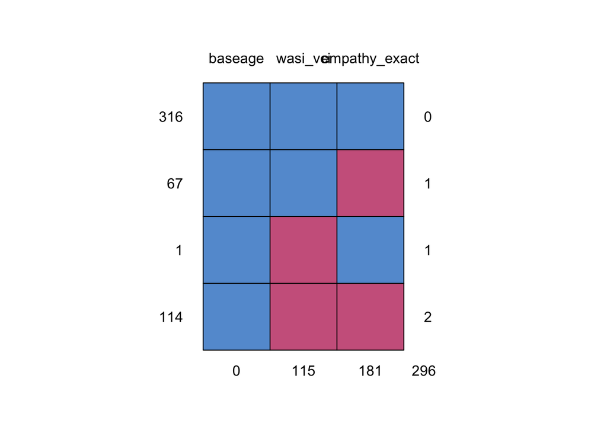

```
##     baseage wasi_vci empathy_exact
## 316       1        1             1   0
## 67        1        1             0   1
## 1         1        0             1   1
## 114       1        0             0   2
##           0      115           181 296
```

```r
# Replace incorrectly placed 0s with NA
alldata$empathy_exact[alldata$empathy_exact == 0] <- NA

# Examine missing data patterns
md.pattern(alldata[,c("empathy_exact", "baseage", "wasi_vci")])
```

```r
# Attrition analysis setup
alldata$miss_empathy_exact <- ifelse(is.na(alldata$empathy_exact), 1, 0)
alldata$miss_baseage <- ifelse(is.na(alldata$baseage), 1, 0)
alldata$miss_wasi_vci <- ifelse(is.na(alldata$wasi_vci), 1, 0)

# Test whether empathy_exact is missing completely at random
t.test(alldata$baseage[alldata$miss_empathy_exact==0], alldata$baseage[alldata$miss_empathy_exact==1], alternative = "two.sided", conf.level = .95, var.equal = TRUE)
```

```
##
##  Two Sample t-test
##
## data:  alldata$baseage[alldata$miss_empathy_exact == 0] and alldata$baseage[alldata$miss_empathy_exact == 1]
## t = 0.37635, df = 496, p-value = 0.7068
## alternative hypothesis: true difference in means is not equal to 0
## 95 percent confidence interval:
##  -0.0802857  0.1183308
## sample estimates:
## mean of x mean of y
##  6.816222  6.797200
```

```r
t.test(alldata$wasi_vci[alldata$miss_empathy_exact==0], alldata$wasi_vci[alldata$miss_empathy_exact==1], alternative = "two.sided", conf.level = .95, var.equal = TRUE)
```

```
##
##  Two Sample t-test
##
## data:  alldata$wasi_vci[alldata$miss_empathy_exact == 0] and alldata$wasi_vci[alldata$miss_empathy_exact == 1]
## t = 3.0514, df = 381, p-value = 0.002437
## alternative hypothesis: true difference in means is not equal to 0
## 95 percent confidence interval:
##  1.725909 7.980118
## sample estimates:
## mean of x mean of y
##  98.98734  94.13433
```

```r
# Test whether wasi_vci is missing completely at random
t.test(alldata$empathy_exact[alldata$miss_wasi_vci==0], alldata$empathy_exact[alldata$miss_wasi_vci==1], alternative = "two.sided", conf.level = .95, var.equal = TRUE)
```

```
##
##  Two Sample t-test
##
## data:  alldata$empathy_exact[alldata$miss_wasi_vci == 0] and alldata$empathy_exact[alldata$miss_wasi_vci == 1]
## t = 1.4115, df = 315, p-value = 0.1591
## alternative hypothesis: true difference in means is not equal to 0
## 95 percent confidence interval:
##  -0.1345011  0.8174125
## sample estimates:
## mean of x mean of y
## 0.6747890 0.3333333
```

```r
t.test(alldata$baseage[alldata$miss_wasi_vci==0], alldata$baseage[alldata$miss_wasi_vci==1], alternative = "two.sided", conf.level = .95, var.equal = TRUE)
```

```
##
##  Two Sample t-test
##
## data:  alldata$baseage[alldata$miss_wasi_vci == 0] and alldata$baseage[alldata$miss_wasi_vci == 1]
## t = 0.80517, df = 496, p-value = 0.4211
## alternative hypothesis: true difference in means is not equal to 0
## 95 percent confidence interval:
##  -0.06686212  0.15971411
## sample estimates:
## mean of x mean of y
##  6.820029  6.773603
```

# Check assumptions

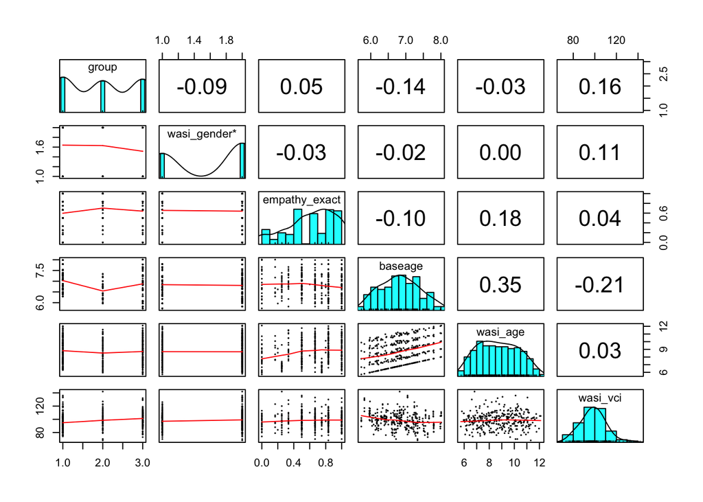

```r
alldata1 %>%
  # Select the variables to be used
  select(group, wasi_gender, empathy_exact, baseage, wasi_age, wasi_vci) %>%
  psych::pairs.panels(ellipses = FALSE, cex = 0.2, cex.cor = 1)
```

The data for baseage, and wasi_vci (the continuous variables being included in the model) appear relatively normal. Data for empathy exact is skewed.

# Write Down Model Equations

Lv-1:
$$\mathrm{empathyexact}_{ti} = \beta_{0i} + \beta_{1i}\mathrm{time}_{ti} + \beta_{2i}\mathrm{verbalpmc}_{ti} + e_{ti}$$
Lv-2:
$$\beta_{0i} = \gamma_{00} + \gamma_{01}\mathrm{baseage}_i + \gamma_{02}\mathrm{verbalpm_i} + \gamma_{03}\mathrm{group}_i+ u_{0i}$$
$$\beta_{1i} = \gamma_{10} + \gamma_{11}\mathrm{verbalpm}_i + \gamma_{12}\mathrm{group}_i + u_{1i}$$
$$\beta_{2i} = \gamma_{20} + \gamma_{21}\mathrm{baseage}_i + \gamma_{22}\mathrm{group}_i + u_{2i}$$

# Baseline Model

```r
#model with just base interaction of year and group, and no random slopes
m0 <- glmmTMB(empathy_exact ~ time + (1 | id),
    data = alldata1,
)

summary(m0)
```

```
##  Family: gaussian  ( identity )
## Formula:          empathy_exact ~ time + (1 | id)
## Data: alldata1
##
##      AIC      BIC   logLik deviance df.resid
##    100.5    115.8    -46.2     92.5      336
##
## Random effects:
##
## Conditional model:
##  Groups   Name        Variance Std.Dev.
##  id       (Intercept) 0.02060  0.1435
##  Residual             0.06286  0.2507
## Number of obs: 340, groups:  id, 83
##
## Dispersion estimate for gaussian family (sigma^2): 0.0629
##
## Conditional model:
##             Estimate Std. Error z value Pr(>|z|)
## (Intercept) 0.497880   0.034208  14.554  < 2e-16 ***
## time        0.044891   0.009765   4.597 4.29e-06 ***
## ---
## Signif. codes:  0 '***' 0.001 '**' 0.01 '*' 0.05 '.' 0.1 ' ' 1
```

# Add in and test covariates and random slopes

```r
#model

m1 <- glmmTMB(empathy_exact ~ time + group + (1 | id),
    data = alldata1,
)

summary(m1)
```

```
##  Family: gaussian  ( identity )
## Formula:          empathy_exact ~ time + group + (1 | id)
## Data: alldata1
##
##      AIC      BIC   logLik deviance df.resid
##    100.2    123.2    -44.1     88.2      334
##
## Random effects:
##
## Conditional model:
##  Groups   Name        Variance Std.Dev.
##  id       (Intercept) 0.01901  0.1379
##  Residual             0.06272  0.2504
## Number of obs: 340, groups:  id, 83
##
## Dispersion estimate for gaussian family (sigma^2): 0.0627
##
## Conditional model:
##             Estimate Std. Error z value Pr(>|z|)
## (Intercept) 0.448237   0.043886  10.214  < 2e-16 ***
## time        0.044775   0.009745   4.595 4.33e-06 ***
## groupMusic  0.106573   0.051102   2.085    0.037 *
## groupSport  0.049212   0.050470   0.975    0.330
## ---
## Signif. codes:  0 '***' 0.001 '**' 0.01 '*' 0.05 '.' 0.1 ' ' 1
```

```r
anova(m0, m1)
```

|  | Df | AIC | BIC | logLik | deviance | Chisq | Chi Df | Pr(>Chisq) |
| --- | --- | --- | --- | --- | --- | --- | --- | --- |
| m0 | 4 | 100.4686 | 115.7844 | -46.23432 | 92.46864 | NA | NA | NA |
| m1 | 6 | 100.1972 | 123.1709 | -44.09861 | 88.19723 | 4.271411 | 2 | 0.1181612 |

```r
#no sig

#add interaction of year and group
m2 <- glmmTMB(empathy_exact ~ time*group + (1 | id),
    data = alldata1,
)
summary(m2)
```

```
##  Family: gaussian  ( identity )
## Formula:          empathy_exact ~ time * group + (1 | id)
## Data: alldata1
##
##      AIC      BIC   logLik deviance df.resid
##    103.8    134.4    -43.9     87.8      332
##
## Random effects:
##
## Conditional model:
##  Groups   Name        Variance Std.Dev.
##  id       (Intercept) 0.01913  0.1383
##  Residual             0.06258  0.2502
## Number of obs: 340, groups:  id, 83
##
## Dispersion estimate for gaussian family (sigma^2): 0.0626
##
## Conditional model:
##                 Estimate Std. Error z value Pr(>|z|)
## (Intercept)     0.462607   0.057027   8.112 4.98e-16 ***
## time            0.039484   0.016563   2.384   0.0171 *
## groupMusic      0.067850   0.083191   0.816   0.4147
## groupSport      0.042610   0.081745   0.521   0.6022
## time:groupMusic 0.014163   0.024021   0.590   0.5554
## time:groupSport 0.002495   0.023545   0.106   0.9156
## ---
## Signif. codes:  0 '***' 0.001 '**' 0.01 '*' 0.05 '.' 0.1 ' ' 1
```

```r
anova(m1, m2)
```

|  | Df | AIC | BIC | logLik | deviance | Chisq | Chi Df | Pr(>Chisq) |
| --- | --- | --- | --- | --- | --- | --- | --- | --- |
| m1 | 6 | 100.1972 | 123.1709 | -44.09861 | 88.19723 | NA | NA | NA |
| m2 | 8 | 103.8072 | 134.4387 | -43.90358 | 87.80717 | 0.3900608 | 2 | 0.8228096 |

```r
#no sig, but this is what we want to test

#add more covariates
#verbal (person mean-centered)
m3 <- glmmTMB(empathy_exact ~ time*group + verbal_pmc + (1 | id),
    data = alldata1,
)
summary(m3)
```

```
##  Family: gaussian  ( identity )
## Formula:          empathy_exact ~ time * group + verbal_pmc + (1 | id)
## Data: alldata1
##
##      AIC      BIC   logLik deviance df.resid
##    105.8    140.3    -43.9     87.8      331
##
## Random effects:
##
## Conditional model:
##  Groups   Name        Variance Std.Dev.
##  id       (Intercept) 0.01913  0.1383
##  Residual             0.06257  0.2501
## Number of obs: 340, groups:  id, 83
##
## Dispersion estimate for gaussian family (sigma^2): 0.0626
##
## Conditional model:
##                  Estimate Std. Error z value Pr(>|z|)
## (Intercept)     0.4629639  0.0572141   8.092 5.88e-16 ***
## time            0.0393529  0.0166501   2.364   0.0181 *
## groupMusic      0.0678535  0.0831904   0.816   0.4147
## groupSport      0.0426009  0.0817444   0.521   0.6023
## verbal_pmc      0.0001811  0.0023488   0.077   0.9385
## time:groupMusic 0.0141635  0.0240212   0.590   0.5554
## time:groupSport 0.0024995  0.0235445   0.106   0.9155
## ---
## Signif. codes:  0 '***' 0.001 '**' 0.01 '*' 0.05 '.' 0.1 ' ' 1
```

```r
anova(m2, m3)
```

|  | Df | AIC | BIC | logLik | deviance | Chisq | Chi Df | Pr(>Chisq) |
| --- | --- | --- | --- | --- | --- | --- | --- | --- |
| m2 | 8 | 103.8072 | 134.4387 | -43.90358 | 87.80717 | NA | NA | NA |
| m3 | 9 | 105.8012 | 140.2617 | -43.90061 | 87.80122 | 0.005947999 | 1 | 0.9385255 |

```r
#is not sig

#verbal (person mean)
m4 <- glmmTMB(empathy_exact ~ time*group + verbal_pm + (1 | id),
    data = alldata1,
)
summary(m4)
```

```
##  Family: gaussian  ( identity )
## Formula:          empathy_exact ~ time * group + verbal_pm + (1 | id)
## Data: alldata1
##
##      AIC      BIC   logLik deviance df.resid
##    105.8    140.3    -43.9     87.8      331
##
## Random effects:
##
## Conditional model:
##  Groups   Name        Variance Std.Dev.
##  id       (Intercept) 0.01915  0.1384
##  Residual             0.06256  0.2501
## Number of obs: 340, groups:  id, 83
##
## Dispersion estimate for gaussian family (sigma^2): 0.0626
##
## Conditional model:
##                   Estimate Std. Error z value Pr(>|z|)
## (Intercept)      0.4863039  0.2023643   2.403   0.0163 *
## time             0.0394789  0.0165613   2.384   0.0171 *
## groupMusic       0.0683625  0.0833003   0.821   0.4118
## groupSport       0.0432857  0.0819354   0.528   0.5973
## verbal_pm       -0.0002457  0.0020130  -0.122   0.9029
## time:groupMusic  0.0141784  0.0240190   0.590   0.5550
## time:groupSport  0.0026226  0.0235649   0.111   0.9114
## ---
## Signif. codes:  0 '***' 0.001 '**' 0.01 '*' 0.05 '.' 0.1 ' ' 1
```

```r
anova(m2, m4)
```

|  | Df | AIC | BIC | logLik | deviance | Chisq | Chi Df | Pr(>Chisq) |
| --- | --- | --- | --- | --- | --- | --- | --- | --- |
| m2 | 8 | 103.8072 | 134.4387 | -43.90358 | 87.80717 | NA | NA | NA |
| m4 | 9 | 105.7923 | 140.2528 | -43.89613 | 87.79226 | 0.01490913 | 1 | 0.9028175 |

```r
#is not sig

# age
m5 <- glmmTMB(empathy_exact ~ time*group + baseage + (1 | id),
    data = alldata1,
)
summary(m5)
```

```
##  Family: gaussian  ( identity )
## Formula:          empathy_exact ~ time * group + baseage + (1 | id)
## Data: alldata1
##
##      AIC      BIC   logLik deviance df.resid
##    105.1    139.6    -43.5     87.1      331
##
## Random effects:
##
## Conditional model:
##  Groups   Name        Variance Std.Dev.
##  id       (Intercept) 0.01885  0.1373
##  Residual             0.06256  0.2501
## Number of obs: 340, groups:  id, 83
##
## Dispersion estimate for gaussian family (sigma^2): 0.0626
##
## Conditional model:
##                  Estimate Std. Error z value Pr(>|z|)
## (Intercept)      0.700937   0.287683   2.437   0.0148 *
## time             0.040059   0.016573   2.417   0.0156 *
## groupMusic       0.053459   0.084799   0.630   0.5284
## groupSport       0.039268   0.081715   0.480   0.6308
## baseage         -0.034157   0.040402  -0.845   0.3979
## time:groupMusic  0.013549   0.024027   0.564   0.5728
## time:groupSport  0.001682   0.023560   0.071   0.9431
## ---
## Signif. codes:  0 '***' 0.001 '**' 0.01 '*' 0.05 '.' 0.1 ' ' 1
```

```r
anova(m2, m5)
```

|  | Df | AIC | BIC | logLik | deviance | Chisq | Chi Df | Pr(>Chisq) |
| --- | --- | --- | --- | --- | --- | --- | --- | --- |
| m2 | 8 | 103.8072 | 134.4387 | -43.90358 | 87.80717 | NA | NA | NA |
| m5 | 9 | 105.0948 | 139.5554 | -43.54742 | 87.09484 | 0.7123271 | 1 | 0.3986724 |

```r
# is not sig

#gender
m6 <- glmmTMB(empathy_exact ~ time*group + wasi_gender + (1 | id),
    data = alldata1,
)
summary(m6)
```

```
##  Family: gaussian  ( identity )
## Formula:          empathy_exact ~ time * group + wasi_gender + (1 | id)
## Data: alldata1
##
##      AIC      BIC   logLik deviance df.resid
##    105.7    140.2    -43.9     87.7      331
##
## Random effects:
##
## Conditional model:
##  Groups   Name        Variance Std.Dev.
##  id       (Intercept) 0.01900  0.1379
##  Residual             0.06262  0.2502
## Number of obs: 340, groups:  id, 83
##
## Dispersion estimate for gaussian family (sigma^2): 0.0626
##
## Conditional model:
##                  Estimate Std. Error z value Pr(>|z|)
## (Intercept)      0.470017   0.062240   7.552  4.3e-14 ***
## time             0.039621   0.016574   2.391   0.0168 *
## groupMusic       0.068029   0.083160   0.818   0.4133
## groupSport       0.042345   0.081718   0.518   0.6043
## wasi_genderm    -0.012629   0.042536  -0.297   0.7665
## time:groupMusic  0.014069   0.024029   0.585   0.5582
## time:groupSport  0.002174   0.023575   0.092   0.9265
## ---
## Signif. codes:  0 '***' 0.001 '**' 0.01 '*' 0.05 '.' 0.1 ' ' 1
```

```r
anova(m2, m6)
```

|  | Df | AIC | BIC | logLik | deviance | Chisq | Chi Df | Pr(>Chisq) |
| --- | --- | --- | --- | --- | --- | --- | --- | --- |
| m2 | 8 | 103.8072 | 134.4387 | -43.90358 | 87.80717 | NA | NA | NA |
| m6 | 9 | 105.7193 | 140.1798 | -43.85963 | 87.71925 | 0.08791435 | 1 | 0.7668456 |

```r
#not sig, gender doesnt seem to improve the model


#test for random slopes

#time
m2.1 <- glmmTMB(empathy_exact ~ time*group +  (time | id),
    data = alldata1,
)
summary(m2.1)
```

```
##  Family: gaussian  ( identity )
## Formula:          empathy_exact ~ time * group + (time | id)
## Data: alldata1
##
##      AIC      BIC   logLik deviance df.resid
##       NA       NA       NA       NA      330
##
## Random effects:
##
## Conditional model:
##  Groups   Name        Variance  Std.Dev.  Corr
##  id       (Intercept) 1.913e-02 1.383e-01
##           time        7.603e-20 2.757e-10 1.00
##  Residual             6.258e-02 2.502e-01
## Number of obs: 340, groups:  id, 83
##
## Dispersion estimate for gaussian family (sigma^2): 0.0626
##
## Conditional model:
##                 Estimate Std. Error z value Pr(>|z|)
## (Intercept)     0.462607   0.057027   8.112 4.98e-16 ***
## time            0.039484   0.016563   2.384   0.0171 *
## groupMusic      0.067850   0.083191   0.816   0.4147
## groupSport      0.042610   0.081745   0.521   0.6022
## time:groupMusic 0.014163   0.024021   0.590   0.5554
## time:groupSport 0.002495   0.023545   0.106   0.9156
## ---
## Signif. codes:  0 '***' 0.001 '**' 0.01 '*' 0.05 '.' 0.1 ' ' 1
```

```r
#model convergence issue

anova(m2, m2.1)
```

|  | Df | AIC | BIC | logLik | deviance | Chisq | Chi Df | Pr(>Chisq) |
| --- | --- | --- | --- | --- | --- | --- | --- | --- |
| m2 | 8 | 103.8072 | 134.4387 | -43.90358 | 87.80717 | NA | NA | NA |
| m2.1 | 10 | NA | NA | NA | NA | NA | 2 | NA |

```r
#this is not sig

confint(m2, parm = "beta_")
```

```
##                        2.5 %     97.5 %    Estimate
## (Intercept)      0.350835657 0.57437897 0.462607315
## time             0.007020906 0.07194735 0.039484128
## groupMusic      -0.095201730 0.23090106 0.067849666
## groupSport      -0.117607436 0.20282679 0.042609676
## time:groupMusic -0.032917810 0.06124467 0.014163430
## time:groupSport -0.043652057 0.04864112 0.002494533
```

# Here’s our final model

```r
summary(m2)
```

```
##  Family: gaussian  ( identity )
## Formula:          empathy_exact ~ time * group + (1 | id)
## Data: alldata1
##
##      AIC      BIC   logLik deviance df.resid
##    103.8    134.4    -43.9     87.8      332
##
## Random effects:
##
## Conditional model:
##  Groups   Name        Variance Std.Dev.
##  id       (Intercept) 0.01913  0.1383
##  Residual             0.06258  0.2502
## Number of obs: 340, groups:  id, 83
##
## Dispersion estimate for gaussian family (sigma^2): 0.0626
##
## Conditional model:
##                 Estimate Std. Error z value Pr(>|z|)
## (Intercept)     0.462607   0.057027   8.112 4.98e-16 ***
## time            0.039484   0.016563   2.384   0.0171 *
## groupMusic      0.067850   0.083191   0.816   0.4147
## groupSport      0.042610   0.081745   0.521   0.6022
## time:groupMusic 0.014163   0.024021   0.590   0.5554
## time:groupSport 0.002495   0.023545   0.106   0.9156
## ---
## Signif. codes:  0 '***' 0.001 '**' 0.01 '*' 0.05 '.' 0.1 ' ' 1
```

# Write Down Final Model Equations

Lv-1:
$$\mathrm{empathyexact}_{ti} = \beta_{0i} + \beta_{1i}\mathrm{time}_{ti} + e_{ti}$$
Lv-2:
$$\beta_{0i} = \gamma_{00} + \gamma_{01}\mathrm{group}_i + u_{0i}$$
$$\beta_{1i} = \gamma_{10} + \gamma_{11}\mathrm{group}_i$$

# Coefficient Table (msummary)

```r
msummary(m2,
  stars=TRUE)
```

|  | Model 1 |
| --- | --- |
| (Intercept) | 0.463*** |
|  | (0.057) |
| time | 0.039* |
|  | (0.017) |
| groupMusic | 0.068 |
|  | (0.083) |
| groupSport | 0.043 |
|  | (0.082) |
| time × groupMusic | 0.014 |
|  | (0.024) |
| time × groupSport | 0.002 |
|  | (0.024) |
| SD (Intercept) | 0.138 |
| SD (Observations) | 0.250 |
| Num.Obs. | 340 |
| R2 Marg. | 0.070 |
| R2 Cond. | 0.287 |
| AIC | 103.8 |
| BIC | 134.4 |
| ICC | 0.2 |
| RMSE | 0.23 |

+ p < 0.1, * p < 0.05, ** p < 0.01, *** p < 0.001

# Plot

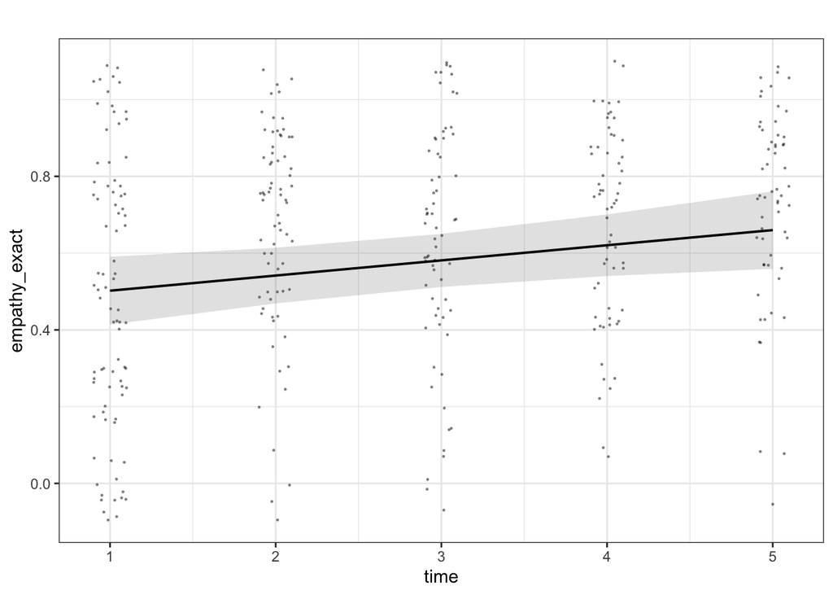

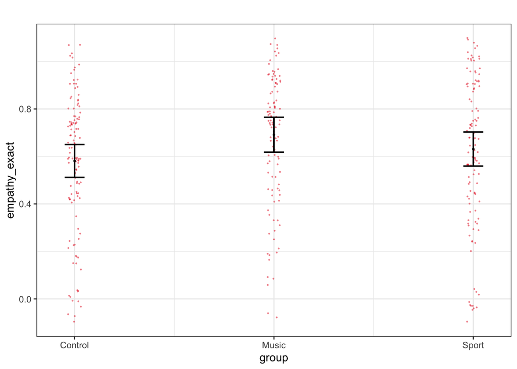

```r
plot_model(m2,
    type = "pred", show.data = TRUE,
    title = "", dot.size = 0.5,
    jitter = 0.1
)
```

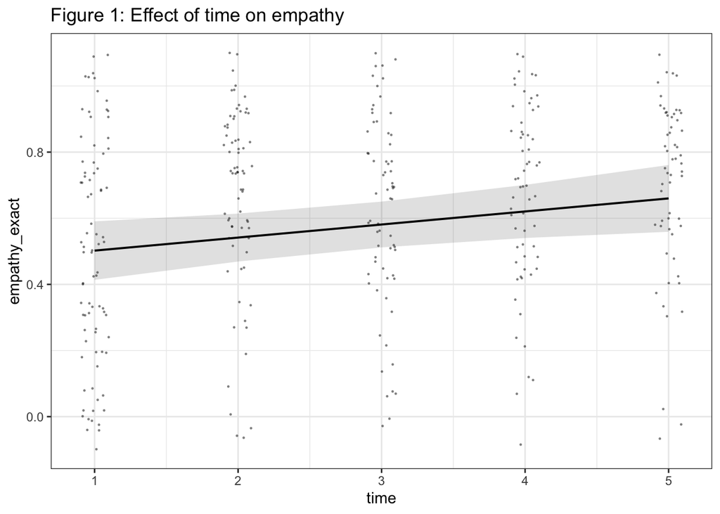

```r
plot_model(m2,
    type = "pred", terms = "time",
    show.data = TRUE, jitter = 0.1,
    title = "Figure 1: Effect of time on empathy ",
    dot.size = 0.5
)
```

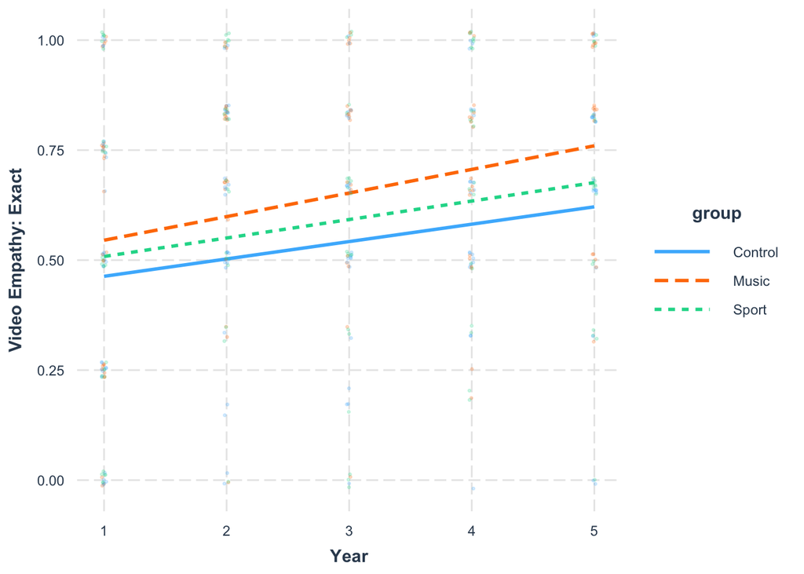

```r
# Interaction plot (year:group)
interact_plot(m2,
              pred = "time",
              modx = "group",
              plot.points = TRUE,
              point.size = 0.5,
              point.alpha = 0.2,
              jitter = 0.02,
              x.label = "Year",
              y.label = "Video Empathy: Exact")
```

#We are going to use Empathy Exact: a more interesting and accurate measure Summary: The results show a predicted significant increase in the VET of 0.039 per year, regardless of group, when holding constant the interaction between time and group (95% CI [0.007, 0.072]). There was no significant effect of group (Music estimate = 0.068, 95% CI [-0.095, 0.231]; Sport estimate = 0.043, 95% CI [-0.118, 0.203]), and no significant interaction between group and time (Time × Music estimate = 0.014, 95% CI [-0.033, 0.061]; Time × Sport estimate = 0.002, 95% CI [-0.044, 0.049]) on the VET, when holding constant the other variables.